# **PROJET STATISTIQUES MSDA1 2023 / 2024**

## **MEMBRES DU GROUPE :**

- Mouhamadou Mansour BA (IIA)
- Mame Peuya DIA (IIA)
- Fatou FALL (SEM)
- Khoudia Bintou FALL (CAA)

**PLAN**

***Introduction***

***Exercice 1 : Simulation de Lois***

- 1.1 Simulation de la loi binomiale B(30, 0.5)
  - Génération d'un échantillon de taille 10 000
  - Tracé de l’histogramme de l’échantillon
  - Interprétation de l'histogramme
- 1.2 Simulation de la loi normale N(3, 0.9)
  - Génération d'un échantillon de taille 10 000
  - Tracé de la fonction de densité de l’échantillon
  - Interprétation de l'histogramme
- 1.3 Simulation de la loi du X² avec 20 degrés de liberté
  - Génération d'un échantillon de taille 10 000
  - Tracé de la fonction de densité de l’échantillon
  - Interprétation de l'histogramme

***Exercice 2 : Méthode de Monte Carlo***

- 2.1 Estimation de l’intégrale I2
  - Utilisation de la méthode de Monte Carlo avec n= 10000
- 2.2 Graphique d’évolution de l’estimation
  - Tracé de la convergence de l’estimation en fonction de n
  - Vérification de la cohérence avec la valeur théorique I2 = Pi/4
  - Interprétation du graphe

***Exercice 3 : Régression Linéaire***

- 3.1 Préparation des données
  - Enregistrement des couples d’observations (xi,yi) dans un format adapté pour Python
- 3.2 Analyse de la relation entre yi et xi
  - Tracé des points (xi,yi)
  - Observation d’une possible liaison linéaire
- 3.3 Calcul de la droite des moindres carrés
  - Estimation des coefficients de la droite de régression
- 3.4 Calcul des valeurs estimées de yi
  - Calcul des ordonnées des yi estimés pour chaque xi
- 3.5 Tracé de la droite de régression
  - Ajout de la droite sur le graphique de dispersion
- 3.6 Estimation de𝑌pour xi=21
  - Calcul de la valeur estimée de𝑌
- 3.7 Calcul de l’écart
  - Calcul de l’écart entre la valeur observée et la valeur estimée pour xi=21
- 3.8 Vérification du passage par le point moyen t (x¯, y¯)
  - Discussion sur la généralisation du passage par le point moyen pour

  toute droite de régression

***Exercice 4 : Données COVID-19 au Sénégal***

- 4.1 Lecture et nettoyage des données
  - Lecture du fichier regions_cas.csv
  - Nettoyage des noms de régions et conversion de la variable date en type datetime
- 4.2 Convertir la variable date en type datetime, et supprimer toutes les lignes ayant des valeurs manquantes
  - Convertir la variable date date en type datetime
  - Supprimer toutes les lignes ayant des valeurs manquantes
- 4.3 Créer une fonction qui retourne un dataframe à 3 colonnes (date, region, maladesparegion). La dernière colonne contiendra le nombre de malades de covid-19 par régions aux différentes dates données
- 4.4 Estimation de λ
- 4.5 Utilisation d'un test statistique pour vérifier si la variable maladesparegion suit une loi de Poisson
- 4.6 Estimation de r et de p.
- 4.7 Création d'une fonction CarteRegions(madate) qui affiche la carte choroplèthe des régions en utilisant le nombre de malades.

***Conclusion***

***INTRODUCTION :***

*Ce document présente les solutions aux exercices de statistiques mathématiques pour le Master 1 en Sciences des données à l’Université Iba Der THIAM de Thiès. Ce projet comprend des simulations de lois de probabilité, une estimation par la méthode de Monte Carlo, une analyse de régression linéaire, et une étude de données COVID-19 au Sénégal.*

# ***Exercice 1 : Simulation de lois***

# *1.1 Simulation de la loi binomiale B(30, 0.5)*

*Dans cette première étape, nous simulons un échantillon de taille 10000 suivant une loi binomiale avec 30 essais et une probabilité de succès de 0,5.*

*- Génération de l'échantillon*

```python
import numpy as np

# Simulation d'un échantillon de taille 10000 suivant une loi binomiale B(30, 0.5)
sample_binomial = np.random.binomial(n=30, p=0.5, size=10000)

# Exemple d'affichage des résultats
print("Premiers éléments de l'échantillon simulé :", sample_binomial[:10])
```

```
Premiers éléments de l'échantillon simulé : [ 9 16 14 15 16 16 11 20 16 12]
```

*- Tracé de l’histogramme de l’échantillon*

*Une fois l'échantillon généré, nous traçons un histogramme pour visualiser la distribution des données. L'histogramme est un graphique qui montre la répartition des valeurs observées dans l'échantillon.Chaque barre de l'histogramme représente le nombre d'observations qui tombent dans un intervalle donné.*

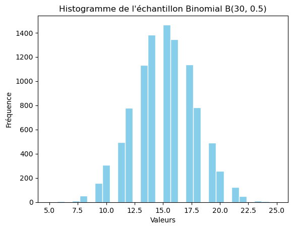

```python
import numpy as np
import matplotlib.pyplot as plt

# Simulation d'un échantillon de taille 10000 suivant une loi binomiale B(30, 0.5)
sample_binomial = np.random.binomial(n=30, p=0.5, size=10000)

# Tracé de l'histogramme
plt.hist(sample_binomial, bins=30, color='skyblue', edgecolor='white', density=False)
plt.title("Histogramme de l'échantillon Binomial B(30, 0.5)")
plt.xlabel("Valeurs")
plt.ylabel("Fréquence")
plt.show()
```

*Dans cet histogramme, l'axe des abscisses représente les différentes valeurs possibles du nombre de succès dans les 30 essais (allant de 0 à 30), tandis que l'axe des ordonnées représente la fréquence (ou le nombre d'occurrences) de chaque valeur dans l'échantillon.*

*- Interprétation de l'histogramme*

*L'histogramme de la loi binomiale devrait présenter une forme en cloche, symétrique autour de la moyenne (15 dans ce cas), représentant le nombre attendu de succès. Étant donné 30 essais et une probabilité de succès de 0.5, la majorité des échantillons devraient se concentrer autour de cette valeur de 15. Les valeurs extrêmes, proches de 0 ou de 30, seront moins fréquentes, ce qui est caractéristique d'une distribution binomiale.*

# *1.2 Simulation de la loi normale N(3, 0.9)*

*Nous simulons un échantillon de taille 10 000 suivant une loi normale avec une moyenne de 3 et un écart-type de 0,9, puis traçons la fonction de densité de l'échantillon.*

*- Génération de l'échantillon*

```python
import numpy as np

# Simulation d'un échantillon de taille 10000 suivant une loi normale N(3, 0.9)
sample_normal = np.random.normal(loc=3, scale=0.9, size=10000)
```

*- Tracé de la fonction de densité de l’échantillon*

*Une fois l'échantillon généré, nous traçons la fonction de densité qui nous permettra de visualiser la répartition des valeurs dans l'échantillon, nous ajoutons également une ligne pour indiquer l'intervalle contenant 0.*

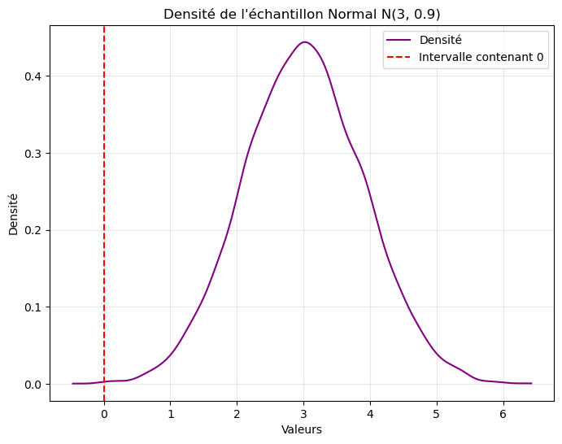

```python
import numpy as np
import matplotlib.pyplot as plt
from scipy.stats import gaussian_kde

# Simulation de l'échantillon (si ce n'est pas déjà fait)
sample_normal = np.random.normal(loc=3, scale=0.9, size=10000)

# Calcul de la densité
density = gaussian_kde(sample_normal)
x_vals = np.linspace(min(sample_normal), max(sample_normal), 1000)
y_vals = density(x_vals)

# Tracé de la densité
plt.figure(figsize=(8, 6))
plt.plot(x_vals, y_vals, color="purple", label="Densité")
plt.axvline(x=0, color="red", linestyle="--", label="Intervalle contenant 0")
plt.title("Densité de l'échantillon Normal N(3, 0.9)")
plt.xlabel("Valeurs")
plt.ylabel("Densité")
plt.legend()
plt.grid(alpha=0.3)
plt.show()
```

*- Interprétation de l'histogramme*

*Le graphique de densité montre la distribution de l'échantillon simulé. La ligne rouge représente un intervalle contenant 0. Comme la loi normale est symétrique, on s'attend à ce que la majorité des valeurs se situent autour de la moyenne 3, avec une dispersion définie par l'écart-type de 0.9.**

# *1.3 Simulation de la loi du X² avec 20 degrés de liberté*

*Tracer la fonction de densité de l’échantillon obtenu. Choisir un intervalle contenant 0 pour domaine de représentation.*

*Enfin, nous simulons un chantillon de taille 10 000 suivant une loi du chi-carré avec 20 degrés de liberté et traçons la fonction de densité de l'échantillon.*

*- Génération de l'échantillon*

```python
import numpy as np

# Simulation d'un échantillon de taille 10000 suivant une loi du χ² avec 20 degrés de liberté
sample_chi2 = np.random.chisquare(df=20, size=10000)
```

*- Tracé de la fonction de densité de l’échantillon*

*Nous traçons ensuite la fonction de densité de l'échantillon pour observer la répartition des valeurs. Comme la loi du chi-carré est asymétrique et prend uniquement des valeurs positives, l'intervalle contenant 0 sera visible sur le graphique.*

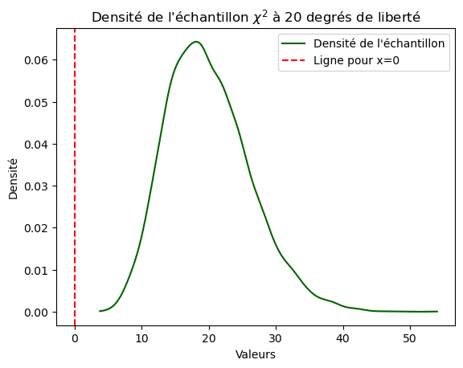

```python
import numpy as np
import matplotlib.pyplot as plt
from scipy.stats import gaussian_kde

# Tracé de la densité de l'échantillon
density = gaussian_kde(sample_chi2)
x_vals = np.linspace(min(sample_chi2), max(sample_chi2), 1000)

plt.plot(x_vals, density(x_vals), color="darkgreen", label="Densité de l'échantillon")
plt.title("Densité de l'échantillon $\\chi^2$ à 20 degrés de liberté")
plt.xlabel("Valeurs")
plt.ylabel("Densité")

# Ligne verticale pour l'intervalle contenant 0
plt.axvline(x=0, color="red", linestyle="dashed", label="Ligne pour x=0")

plt.legend()
plt.show()
```

# ***Exercice 2 : Méthode de Monte Carlo***

# *2.1 Estimation de l’intégrale I2*

*- Utilisation de la méthode de Monte Carlo avec n= 10000*

*Nous estimons l’intégrale I2 à l’aide de la méthode de `Monte Carlo`. Cette méthode consiste à générer aléatoirement des points dans l’intervalle [0,1] et à calculer la moyenne des valeurs de la fonction f(x) évaluée en ces points. Avec n = 10 000simulations, l’estimation obtenue sera comparée à la valeur théorique Pi/4.*

```python
import numpy as np

# Nombre de simulations
n = 10000

# Simulation de points uniformément distribués sur [0, 1]
x = np.random.uniform(0, 1, n)

# Fonction à intégrer : sqrt(1 - x^2)
f_x = np.sqrt(1 - x**2)

# Estimation de l'intégrale par la méthode de Monte Carlo
I2_estimation = np.mean(f_x)

# Affichage de l'estimation
print(f"Estimation de I2 par la méthode de Monte Carlo avec n = {n} : {I2_estimation}")

# Valeur théorique de I2
I2_theorique = np.pi / 4
print(f"Valeur théorique de I2 : {I2_theorique}")
```

```
Estimation de I2 par la méthode de Monte Carlo avec n = 10000 : 0.7844393124397243
Valeur théorique de I2 : 0.7853981633974483
```

# *2.2 Graphique d’évolution de l’estimation*

*- Vérification de la cohérence avec la valeur théorique I2 = Pi/4*

*Pour cette partie, nous visualisons comment l'estimation de I2, obtenue par `la méthode de Monte Carlo`, évolue à mesure que le nombre de simulations augmente. L'objectif est de vérifier la convergence de cette estimation vers la valeur théorique I2 = Pi/4.*

*Le graphique montre la progression de l'estimation cumulée après chaque simulation. Une ligne horizontale représentant la valeur théorique Pi/4 est ajoutée comme référence visuelle pour comparer les estimations successives. Cette approche permet de vérifier la cohérence de la méthode utilisée et d'observer comment la précision s'améliore avec un plus grand nombre de simulations.*

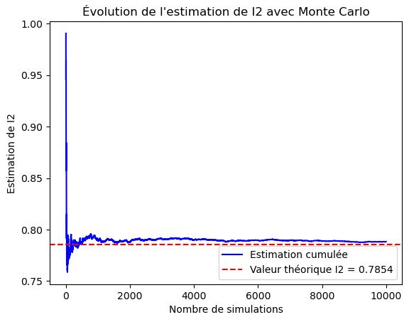

```python
import numpy as np
import matplotlib.pyplot as plt

# Nombre de simulations
n = 10000

# Simulation de points uniformément distribués sur [0, 1]
x = np.random.uniform(0, 1, n)

# Fonction à intégrer : sqrt(1 - x^2)
f_x = np.sqrt(1 - x**2)

# Estimation de l'intégrale par la méthode de Monte Carlo (cumulative)
estimation_progression = np.cumsum(f_x) / np.arange(1, n+1)

# Valeur théorique de I2
I2_theorique = np.pi / 4

# Visualisation de l'évolution de l'estimation
plt.plot(np.arange(1, n+1), estimation_progression, color='blue', label="Estimation cumulée")
plt.axhline(y=I2_theorique, color='red', linestyle='--', label=f"Valeur théorique I2 = {I2_theorique:.4f}")

# Titre et labels
plt.xlabel("Nombre de simulations")
plt.ylabel("Estimation de I2")
plt.title("Évolution de l'estimation de I2 avec Monte Carlo")

# Légende
plt.legend(loc='lower right')

# Affichage
plt.show()
```

*- Interprétation du graphe*

*Le graphique montre l'évolution de l'estimation de I2 en fonction du nombre de simulations n. La courbe bleue correspond à l'estimation cumulative de I2, tandis que la ligne rouge horizontale représente la valeur théorique I2 = Pi/4.*

*On observe que l’estimation devient de plus en plus stable à mesure que n augmente, convergeant vers la valeur théorique. Cette stabilité indique la validité de la méthode de Monte Carlo pour estimer des intégrales. Pour n = 10 000, les écarts entre les estimations successives et la valeur théorique deviennent négligeables, démontrant que la précision s’améliore avec un plus grand nombre de simulations.*

# ***Exercice 3 : Régression Linéaire***

# *3.1 Préparation des données*

*Enregistrement des couples d’observations (xi,yi) dans un format adapté pour Python*

***- Importons d'abord les bibliothèques nécessaires :***

```python
import numpy as np
import matplotlib.pyplot as plt
from sklearn.linear_model import LinearRegression
from sklearn.metrics import mean_squared_error
```

***- Enregistrer les données :***

```python
# Créer un data.frame pour regrouper les données
donnees <- data.frame(x = c(18, 7, 14, 31, 21, 5, 11, 16, 26, 29),
                      y = c(55, 17, 36, 85, 62, 18, 33, 41, 63, 87))

# Exporter les données au format CSV
write.csv(donnees, "donnees.csv", row.names = FALSE)

cat("Les données ont été enregistrées dans le fichier 'donnees.csv'.\n")
```

[output not shown]

***- Affichage du fichier donnees.csv***

```python
import pandas as pd
donnees = pd.read_csv("donnees.csv")
print(donnees)
```

```
    x   y
0  18  55
1   7  17
2  14  36
3  31  85
4  21  62
5   5  18
6  11  33
7  16  41
8  26  63
9  29  87
```

*Les vecteurs x et y contiennent les couples d'observations. Cela correspond à la préparation des données pour l'analyse de régression linéaire.*

# *3.2 Analyse de la relation entre yi et xi*

*- Tracé des points (xi,yi)*

*- Observation d’une possible liaison linéaire*

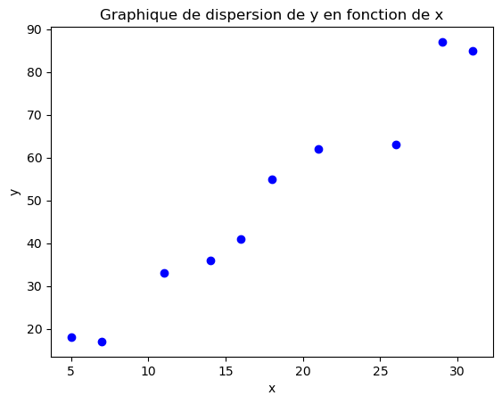

```python
# Données (x et y)
x = [18, 7, 14, 31, 21, 5, 11, 16, 26, 29]
y = [55, 17, 36, 85, 62, 18, 33, 41, 63, 87]

# Tracer un graphique de dispersion
plt.scatter(x, y, color='blue')

# Ajouter un titre et des labels
plt.title('Graphique de dispersion de y en fonction de x')
plt.xlabel('x')
plt.ylabel('y')

# Afficher le graphique
plt.show()
```

*Ce graphique permet de visualiser les points et d’observer une éventuelle relation linéaire entre x et y.*

# *3.3 Calcul de la droite des moindres carrés*

*- Estimation des coefficients de la droite de régression*

```python
# Données (x et y)
x = np.array([18, 7, 14, 31, 21, 5, 11, 16, 26, 29]).reshape(-1, 1)
y = np.array([55, 17, 36, 85, 62, 18, 33, 41, 63, 87])

# Ajustement d'une droite de régression linéaire
model = LinearRegression()
model.fit(x, y)

# Estimation des coefficients (pente et intercept)
slope = model.coef_[0]
intercept = model.intercept_

# Afficher les coefficients
print("Coefficients de la droite des moindres carrés :")
print(f"Pente (slope) : {slope}")
print(f"Ordonnée à l'origine (intercept) : {intercept}")
```

```
Coefficients de la droite des moindres carrés :
Pente (slope) : 2.7347560975609753
Ordonnée à l'origine (intercept) : 1.0213414634146432
```

*Le modèle ajuste la droite des moindres carrés. Les coefficients de régression sont correctement extraits et affichés.*

# *3.4 Calcul des valeurs estimées de yi*

*- Calcul des ordonnées des yi estimés pour chaque xi*

```python
# Calculer les valeurs estimées de y
y_estime = model.predict(x)

# Afficher les ordonnées estimées pour chaque x_i
print("Ordonnées estimées pour chaque xi :")
print(y_estime)
```

```
Ordonnées estimées pour chaque xi :
[50.24695122 20.16463415 39.30792683 85.79878049 58.45121951 14.69512195
 31.10365854 44.77743902 72.125      80.32926829]
```

*Cette étape calcule les yi estimés pour chaque xi. Ces valeurs sont essentielles pour tracer la droite et évaluer la qualité du modèle.*

# *3.5 Tracé de la droite de régression*

*- Ajout de la droite sur le graphique de dispersion*

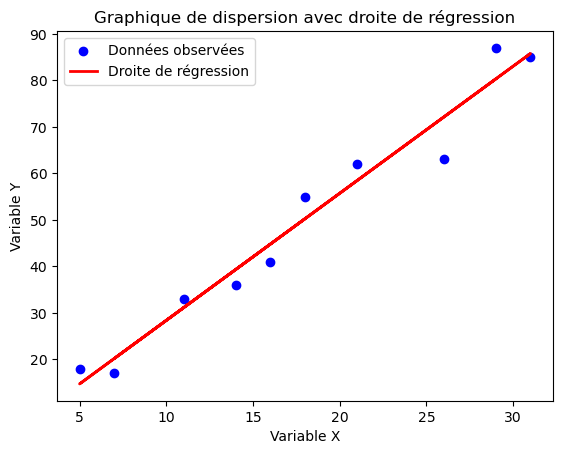

```python
import matplotlib.pyplot as plt
import numpy as np
from sklearn.linear_model import LinearRegression

# Données (x et y)
x = np.array([18, 7, 14, 31, 21, 5, 11, 16, 26, 29]).reshape(-1, 1)
y = np.array([55, 17, 36, 85, 62, 18, 33, 41, 63, 87])

# Ajuster un modèle de régression linéaire
model = LinearRegression()
model.fit(x, y)

# Calculer les valeurs estimées de y (droite de régression)
y_estime = model.predict(x)

# Tracer le graphique de dispersion
plt.scatter(x, y, color='blue', label='Données observées')

# Ajouter la droite de régression
plt.plot(x, y_estime, color='red', linewidth=2, label='Droite de régression')

# Ajouter un titre et des labels
plt.title('Graphique de dispersion avec droite de régression')
plt.xlabel('Variable X')
plt.ylabel('Variable Y')

# Ajouter une légende
plt.legend()

# Afficher le graphique
plt.show()
```

*La droite de régression est correctement ajoutée au graphique de dispersion pour visualiser l’ajustement.*

# *3.6 Estimation de 𝑌 pour xi=21*

```python
# Calculer la valeur estimée de y pour xi = 21
x_new = 21
y_estime_21 = slope * x_new + intercept
print(f"Estimation de Y pour xi = 21 : {y_estime_21}")
```

```
Estimation de Y pour xi = 21 : 58.451219512195124
```

*Cette section calcule Y pour xi = 21 à partir du modèle ajusté. C’est une application classique de la prédiction avec un modèle linéaire.*

# *3.7 Calcul de l’écart*

*- Calcul de l’écart entre la valeur observée et la valeur estimée pour xi = 21*

```python
# Calculer l'écart entre la valeur observée et la valeur estimée pour x = 21
y_observe_21 = donnees.loc[donnees['x'] == 21, 'y'].values[0]
ecart = y_observe_21 - y_estime_21
print(f"Écart entre la valeur observée et estimée pour x = 21 : {ecart} (L'écart est appelé résidu)")
```

```
Écart entre la valeur observée et estimée pour x = 21 : 3.5487804878048763 (L'écart est appelé résidu)
```

*`L’écart (ou résidu)` est correctement calculé comme la différence entre la valeur observée et la valeur prédite.*

# *3.8 Vérification du passage par le point moyen t (x¯, y¯)*

*-Discussion sur la généralisation du passage par le point moyen pour toute droite de régression*

```python
# Calculer les moyennes de x et y
x_bar = donnees['x'].mean()
y_bar = donnees['y'].mean()

# Vérifier si la droite passe par (x̄, ȳ)
y_estime_bar = slope * x_bar + intercept
passe_par_moyen = np.isclose(y_estime_bar, y_bar)
print(f"Point moyen (x̄, ȳ) : ({x_bar}, {y_bar})")
print(f"La droite passe-t-elle par (x̄, ȳ) ? : {passe_par_moyen}")
```

```
Point moyen (x̄, ȳ) : (17.8, 49.7)
La droite passe-t-elle par (x̄, ȳ) ? : True
```

*Cette vérification est importante pour confirmer que la droite de régression passe bien par le barycentre (x¯, y¯), ce qui est une propriété fondamentale des moindres carrés.*

# ***Exercice 4 : Données COVID-19 Sénégal***

# *4.1 Lecture et nettoyage des données*

*-Lecture du fichier regions_cas.csv*

```python
import pandas as pd

# Charger un fichier Excel
dataframe = pd.read_excel("regions_cas.xlsx")  # Utilise la bonne fonction pour les fichiers Excel

# Afficher un aperçu des données
print(dataframe)
```

```
          DATE  DAKAR  DIOURBEL  FATICK  KAFFRINE  KAOLACK  KÉDOUGOU  KOLDA  \
0   2020-03-29     85        26       1         0        0         0      0
1   2020-03-31    117        26       1         0        0         0      0
2   2020-04-01    131        26       1         0        0         0      0
3   2020-04-02    136        26       1         0        0         0      0
4   2020-04-03    140        26       1         0        0         0      7
..         ...    ...       ...     ...       ...      ...       ...    ...
174 2020-10-14  10465       744     313        20      273       218    215
175 2020-10-16  10487       744     314        20      274       218    215
176 2020-10-17  10507       744     314        20      274       218    215
177 2020-10-19  10533       746     314        20      274       218    215
178 2020-10-20  10537       746     314        20      274       218    215

     LOUGA  MATAM  SAINT LOUIS  SÉDHIOU  TAMBACOUNDA  THIÈS  ZIGUINCHOR
0        0      0            2        0            0     24           3
1        0      0            2        0            0     26           3
2        0      0            3        0            0     26           3
3        0      0            3        0            0     26           3
4        0      0            3        0            1     26           3
..     ...    ...          ...      ...          ...    ...         ...
174     70     86          297      151          111   1843         563
175     70     88          297      151          111   1854         564
176     70     88          297      151          111   1857         565
177     70     92          297      151          111   1866         566
178     72     92          298      151          111   1886         566

[179 rows x 15 columns]
```

*-Nettoyage des noms de régions et mettre la première lettre en majuscule*

```python
from unidecode import unidecode
import pandas as pd

# Nettoyage des noms des colonnes en enlevant les accents et les points, et en mettant la première lettre en majuscule
dataframe.columns = [unidecode(col).replace('.', '').title() for col in dataframe.columns]

# Affichage des noms des colonnes après nettoyage
print("Les noms des colonnes après nettoyage :")
print(dataframe.columns)

# Réorganisation des données pour avoir une colonne "Date", une colonne "Region" et une colonne "Malades"
données_transformées = pd.melt(dataframe, id_vars=["Date"], var_name="Region", value_name="Malades")

# Affichage des données après la transformation
print("Les données transformées :")
print(données_transformées)

# Sauvegarder les données dans un fichier CSV
données_transformées.to_csv("covid_data.csv", index=False)
```

```
Les noms des colonnes après nettoyage :
Index(['Date', 'Dakar', 'Diourbel', 'Fatick', 'Kaffrine', 'Kaolack',
       'Kedougou', 'Kolda', 'Louga', 'Matam', 'Saint Louis', 'Sedhiou',
       'Tambacounda', 'Thies', 'Ziguinchor'],
      dtype='object')
Les données transformées :
           Date      Region  Malades
0    2020-03-29       Dakar       85
1    2020-03-31       Dakar      117
2    2020-04-01       Dakar      131
3    2020-04-02       Dakar      136
4    2020-04-03       Dakar      140
...         ...         ...      ...
2501 2020-10-14  Ziguinchor      563
2502 2020-10-16  Ziguinchor      564
2503 2020-10-17  Ziguinchor      565
2504 2020-10-19  Ziguinchor      566
2505 2020-10-20  Ziguinchor      566

[2506 rows x 3 columns]
```

# *4.2 Conversion de la variable date en type datetime et suppression de toutes les lignes ayant des valeurs manquantes (s’il en existe)*

*- Conversion de la variable date en type datetime*

```python
#Convertir la variable date en datetime
#Utilisons la fonction pd.to_datetime pour convertir la date
données_transformées['Date'] = pd.to_datetime(données_transformées['Date'], errors='coerce')  # Utilisation de 'coerce' pour gérer les erreurs
print(données_transformées)
```

```
           Date      Region  Malades
0    2020-03-29       Dakar       85
1    2020-03-31       Dakar      117
2    2020-04-01       Dakar      131
3    2020-04-02       Dakar      136
4    2020-04-03       Dakar      140
...         ...         ...      ...
2501 2020-10-14  Ziguinchor      563
2502 2020-10-16  Ziguinchor      564
2503 2020-10-17  Ziguinchor      565
2504 2020-10-19  Ziguinchor      566
2505 2020-10-20  Ziguinchor      566

[2506 rows x 3 columns]
```

*- Supprimer toutes les lignes ayant des valeurs manquantes (s’il en existe)*

```python
#Utilisons la méthode `dropna` pour supprimer les lignes qui ont des valeurs manquantes
données_transformées = données_transformées.dropna()
print(données_transformées)
```

```
           Date      Region  Malades
0    2020-03-29       Dakar       85
1    2020-03-31       Dakar      117
2    2020-04-01       Dakar      131
3    2020-04-02       Dakar      136
4    2020-04-03       Dakar      140
...         ...         ...      ...
2501 2020-10-14  Ziguinchor      563
2502 2020-10-16  Ziguinchor      564
2503 2020-10-17  Ziguinchor      565
2504 2020-10-19  Ziguinchor      566
2505 2020-10-20  Ziguinchor      566

[2506 rows x 3 columns]
```

# *4.3 Création d'une fonction qui retourne un dataframe à 3 colonnes (date, region, maladesparegion). La dernière colonne contiendra le nombre de malades de covid-19 par régions aux différentes dates données.*

```python
import pandas as pd
import unidecode
#Créons une fonction qui retourne un dataframe à trois colonnes date,region et maladesparregion:

def transformation(données_transformées):

    # Utilisation de melt pour transformer les régions en ligne
    données_transformées = pd.melt(dataframe, id_vars=["Date"], var_name="Region", value_name="maladesparregion")

    return données_transformées


données_nouvelles = transformation(données_transformées)
print(données_nouvelles)
```

```
           Date      Region  maladesparregion
0    2020-03-29       Dakar                85
1    2020-03-31       Dakar               117
2    2020-04-01       Dakar               131
3    2020-04-02       Dakar               136
4    2020-04-03       Dakar               140
...         ...         ...               ...
2501 2020-10-14  Ziguinchor               563
2502 2020-10-16  Ziguinchor               564
2503 2020-10-17  Ziguinchor               565
2504 2020-10-19  Ziguinchor               566
2505 2020-10-20  Ziguinchor               566

[2506 rows x 3 columns]
```

# *4.4 Estimer de λ*

```python
#Calculons la moyenne de la colonne maladesparregion:
moy = données_nouvelles['maladesparregion'].mean()
print( "λ =",moy)
```

```
λ = 534.425778132482
```

# *4.5 Utilisation d'un test statistique pour vérifier si la variable maladesparegion suit une loi de Poisson*

```python
import numpy as np
import scipy.stats as stats

# Estimation du paramètre λ à partir de la moyenne des données
moy = données_nouvelles['maladesparregion'].mean()
estimation = moy  # λ est estimé par la moyenne des malades

# Définir le nombre de classes (bins) pour l'histogramme
nbre_classe = np.arange(données_nouvelles['maladesparregion'].min(), données_nouvelles['maladesparregion'].max() + 1)

# Calcul des fréquences observées dans les différentes classes
observed_frequencies, bin_edges = np.histogram(données_nouvelles['maladesparregion'], bins=nbre_classe)

# Calcul des fréquences théoriques attendues pour chaque bin sous l'hypothèse de Poisson
expected_frequencies = []
for i in range(len(nbre_classe) - 1):
    # Calcul de la probabilité d'avoir un nombre de malades dans chaque intervalle
    prob_range = stats.poisson.cdf(nbre_classe[i+1], estimation) - stats.poisson.cdf(nbre_classe[i], estimation)
    expected_frequencies.append(prob_range)

# Normalisation pour avoir la même taille que les fréquences observées
expected_frequencies = np.array(expected_frequencies) * len(données_nouvelles)

# Ajouter une petite constante pour éviter les zéros dans les fréquences attendues
# Cela permet d'éviter la division par zéro ou les erreurs dans le test du chi carré
expected_frequencies = np.maximum(expected_frequencies, 1e-10)

# Effectuer le test du chi carré
chi2_stat, p_value = stats.chisquare(observed_frequencies, expected_frequencies)

# Afficher les résultats
print(f"Statistique du test chi carré : {chi2_stat}")
print(f"Valeur p du test : {p_value}")

# Interpréter le résultat
if p_value < 0.05:
    print("Nous rejetons l'hypothèse nulle : les données ne suivent pas une loi de Poisson.")
else:
    print("Nous ne rejetons pas l'hypothèse nulle : les données suivent probablement une loi de Poisson.")

# *4.6 Estimation de r et de p*

# Calcul de la moyenne et de la variance des données
moy = données_nouvelles['maladesparregion'].mean()
var = données_nouvelles['maladesparregion'].var()

# Estimation de p et r
p = moy / var
r = moy * p / (1 - p)

print(f"Estimation du paramètre p : {p}")
print(f"Estimation du paramètre r : {r}")
```

```
Statistique du test chi carré : 976086011197701.8
Valeur p du test : 0.0
Nous rejetons l'hypothèse nulle : les données ne suivent pas une loi de Poisson.
Estimation du paramètre p : 0.00018761959852824374
Estimation du paramètre r : 0.10028756584920254
```

# *4.6 Estimation de r et de p*

```python
import numpy as np

# Calcul de la moyenne et de la variance des données
moy = données_nouvelles['maladesparregion'].mean()
var = données_nouvelles['maladesparregion'].var()

# Estimation de p et r
p = moy / var
r = moy* p / (1 - p)

print(f"Estimation du paramètre p : {p}")
print(f"Estimation du paramètre r : {r}")
```

```
Estimation du paramètre p : 0.00018761959852824374
Estimation du paramètre r : 0.10028756584920254
```

# *4.7 Créstion de la fonction CarteRegions(madate) qui affiche la carte choroplèthe des régions en utilisant le nombre de malades*

```python
pip install geopandas matplotlib pandas
```

```python
pip install folium
```

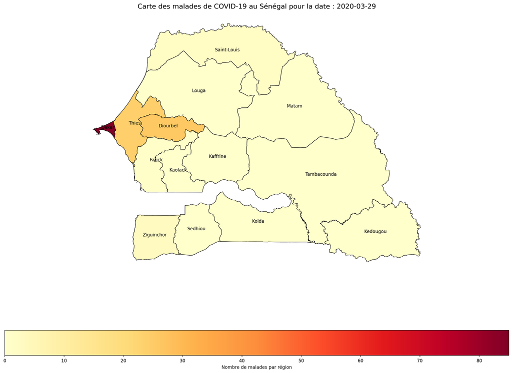

```python
import geopandas as gpd
import pandas as pd
import matplotlib.pyplot as plt
from unidecode import unidecode

def CarteRegions(madate, shapefile_path="gadm41_SEN_1.shp", data_file="covid_data.csv"):
    # Charger les données géographiques depuis le Shapefile
    geo_data = gpd.read_file(shapefile_path)

    # Charger les données des malades depuis le fichier CSV
    data = pd.read_csv(data_file)

    # Filtrer les données pour la date donnée
    data_date = data[data["Date"] == madate].copy()  # Utiliser `.copy()` pour éviter les problèmes liés aux vues

    # Vérifier si des données existent pour la date donnée
    if data_date.empty:
        print(f"Aucune donnée disponible pour la date : {madate}")
        return

    # Normaliser les noms des régions
    geo_data["Region"] = geo_data["NAME_1"].str.strip().str.title()
    geo_data["Region"] = geo_data["Region"].apply(unidecode)
    data_date.loc[:, "Region"] = data_date["Region"].str.strip().str.title()
    data_date.loc[:, "Region"] = data_date["Region"].apply(unidecode)

    # Correction spécifique pour "Saint Louis"
    data_date.loc[:, "Region"] = data_date["Region"].replace({"Saint Louis": "Saint-Louis"})

    # Fusionner les données géographiques avec les données des malades
    geo_merged = geo_data.merge(data_date, on="Region", how="left")

    # Créer une figure pour la carte
    fig, ax = plt.subplots(1, 1, figsize=(20, 15), dpi=200)

    # Tracer la carte avec les données des malades
    geo_merged.plot(
        column="Malades",  # Colonne à utiliser pour la coloration
        cmap="YlOrRd",  # Palette de couleurs
        linewidth=0.8,
        ax=ax,
        edgecolor="black",
        legend=True,
        legend_kwds={"label": "Nombre de malades par région", "orientation": "horizontal"}
    )

    # Ajouter les noms des régions sur la carte
    for _, row in geo_merged.iterrows():
        if not pd.isna(row["Malades"]):  # Vérifier qu'il y a des données
            if row["geometry"].centroid.is_empty:
                continue
            x, y = row["geometry"].centroid.x, row["geometry"].centroid.y
            ax.annotate(
                text=row["Region"],
                xy=(x, y),
                horizontalalignment="center",
                fontsize=10,
                color="black"
            )

    # Ajouter un titre
    ax.set_title(f"Carte des malades de COVID-19 au Sénégal pour la date : {madate}", fontsize=15)

    # Supprimer les axes
    ax.axis("off")

    # Afficher la carte
    plt.show()

# Exemple d'appel de la fonction
CarteRegions("2020-03-29", shapefile_path="gadm41_SEN_1.shp")
```

***Conclusion :***

*Ce projet de statistiques a permis d'explorer des aspects fondamentaux et avancés de la statistique appliquée à travers des simulations, des méthodes numériques, l’analyse de données et la modélisation statistique.*

- Les simulations réalisées dans l’Exercice 1 ont renforcé la compréhension des propriétés des lois probabilistes et leur représentation graphique.
- L’approche Monte Carlo de l’Exercice 2 a illustré la puissance des méthodes stochastiques pour l’estimation numérique, mettant en évidence la convergence vers une valeur théorique.
- L’analyse de régression linéaire dans l’Exercice 3 a permis d’approfondir les compétences en modélisation, en validant des hypothèses et en estimant des relations entre variables.
- L’analyse des données COVID-19 dans l’Exercice 4 a démontré l’utilité des outils statistiques dans des problématiques réelles, intégrant modélisation, tests statistiques et visualisation avancée.

*Ce projet met en lumière l’interdisciplinarité des sciences des données, combinant statistiques, programmation et visualisation pour résoudre des problèmes concrets. Il offre une base solide pour des applications futures, que ce soit dans le domaine académique ou professionnel.*